# The LASSO: A Practical Guide for Psychology Research

Statistical Consulting Resource

2026-03-20

# 1 Introduction

## 1.1 What is LASSO?

**LASSO** stands for **Least Absolute Shrinkage and Selection Operator**. It is a regularized regression technique that simultaneously performs:

1. **Coefficient estimation** — fitting a regression model to your data
2. **Variable selection** — automatically shrinking some coefficients to exactly zero, effectively removing irrelevant predictors

LASSO was introduced by [Robert Tibshirani (1996)](https://doi.org/10.1111/j.2517-6161.1996.tb02080.x) and has since become one of the most widely used methods in modern statistics and machine learning.

## 1.2 The Core Idea

In **Ordinary Least Squares (OLS)**, we minimize the residual sum of squares:

$$\text{Minimize: } \sum_{i=1}^{n}(y_i -
\beta_0 - \sum_{j=1}^{p}\beta_j x_{ij})^2$$

**LASSO** adds a penalty term — the sum of the absolute values of the coefficients, multiplied by a tuning parameter $\lambda$:

$$\text{Minimize: } \sum_{i=1}^{n}(y_i -
\beta_0 - \sum_{j=1}^{p}\beta_j x_{ij})^2 + \lambda
\sum_{j=1}^{p}|\beta_j|$$

- When $\lambda = 0$: You get standard OLS
- As $\lambda \to \infty$: All coefficients are shrunk to zero
- The optimal $\lambda$ is chosen via **cross-validation**

# 2 Comparison with Other Methods

## 2.1 Overview Table

| Feature | OLS / MLE | Ridge Regression | LASSO | Elastic Net |
| --- | --- | --- | --- | --- |
| **Penalty** | None | L2 ($\sum \beta_j^2$) | L1 ($\sum \|\beta_j\|$) | L1 + L2 combined |
| **Variable Selection** | No | No | Yes | Yes |
| **Handles Multicollinearity** | Poorly | Well | Moderately | Well |
| **Bias** | Unbiased | Biased | Biased | Biased |
| **Variance** | Can be high | Lower | Lower | Lower |
| **Best When** | $n \gg p$, few predictors | Correlated predictors | Sparse models | Correlated + sparse |

## 2.2 OLS / Maximum Likelihood Estimation

- Produces **unbiased** estimates under classical assumptions (normality, homoscedasticity, independence)
- Never sets a coefficient to zero — all predictors remain in the model
- Tends to **overfit** when the number of predictors is large relative to the sample size
- Low bias, but can have **high variance**

## 2.3 Ridge Regression (L2 Penalty)

- Adds a penalty on the **squared** coefficients: $\lambda \sum \beta_j^2$
- Shrinks coefficients toward zero but **never exactly to zero**
- Handles **multicollinearity** well
- Does **not** perform variable selection

## 2.4 LASSO (L1 Penalty)

- Adds a penalty on the **absolute** coefficients: $\lambda \sum |\beta_j|$
- Can shrink coefficients **exactly to zero** → automatic variable selection
- Introduces **bias** in exchange for reduced **variance** (the bias-variance tradeoff)
- May struggle with groups of highly correlated predictors (arbitrarily picks one)

## 2.5 Elastic Net (L1 + L2 Combined)

- Combines both penalties: $\lambda_1 \sum |\beta_j| + \lambda_2 \sum \beta_j^2$
- Gets the **variable selection** of LASSO with the **grouping effect** of Ridge
- Particularly useful in psychology where predictor variables are often correlated (e.g., subscales of related constructs)

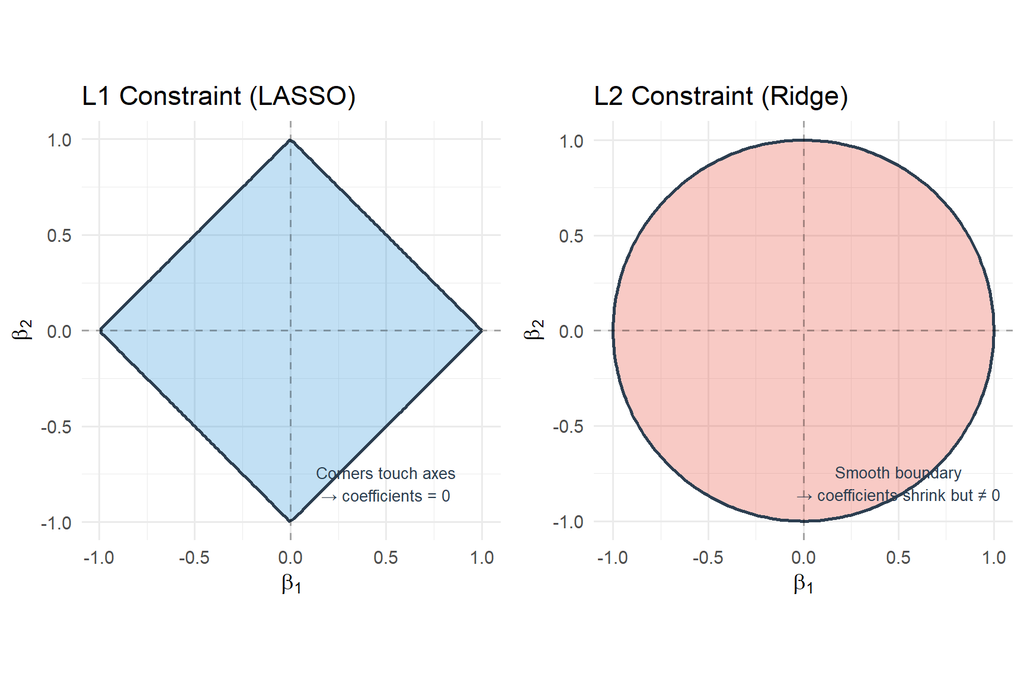

Visualization of L1 (LASSO) vs L2 (Ridge) constraint regions

```r
library(ggplot2)
library(gridExtra)

# Create constraint region plots
theta <- seq(0, 2 * pi, length.out = 300)

# L1 (LASSO) - Diamond
l1_x <- cos(theta)
l1_y <- sin(theta)
l1_r <- 1 / (abs(cos(theta)) + abs(sin(theta)))
l1_df <- data.frame(x = l1_r * cos(theta), y = l1_r * sin(theta))

# L2 (Ridge) - Circle
l2_df <- data.frame(x = cos(theta), y = sin(theta))

p1 <- ggplot(l1_df, aes(x, y)) +
  geom_polygon(fill = "#3498db", alpha = 0.3, color = "#2c3e50", linewidth = 1) +
  geom_hline(yintercept = 0, linetype = "dashed", alpha = 0.3) +
  geom_vline(xintercept = 0, linetype = "dashed", alpha = 0.3) +
  coord_fixed() +
  labs(title = "L1 Constraint (LASSO)", x = expression(beta[1]), y = expression(beta[2])) +
  theme_minimal(base_size = 14) +
  annotate("text", x = 0.5, y = -0.8, label = "Corners touch axes\n→ coefficients = 0",
           size = 3.5, color = "#2c3e50")

p2 <- ggplot(l2_df, aes(x, y)) +
  geom_polygon(fill = "#e74c3c", alpha = 0.3, color = "#2c3e50", linewidth = 1) +
  geom_hline(yintercept = 0, linetype = "dashed", alpha = 0.3) +
  geom_vline(xintercept = 0, linetype = "dashed", alpha = 0.3) +
  coord_fixed() +
  labs(title = "L2 Constraint (Ridge)", x = expression(beta[1]), y = expression(beta[2])) +
  theme_minimal(base_size = 14) +
  annotate("text", x = 0.5, y = -0.8, label = "Smooth boundary\n→ coefficients shrink but ≠ 0",
           size = 3.5, color = "#2c3e50")

grid.arrange(p1, p2, ncol = 2)
```

> **Why does LASSO set coefficients to zero but Ridge doesn’t?** The diamond shape of the L1 constraint region has corners that sit on the axes. When the OLS solution’s contour lines intersect this diamond, they’re most likely to hit a corner — where one or more coefficients are exactly zero.

# 3 When to Use LASSO in Psychology Research

## 3.1 Ideal Scenarios

### 3.1.1 Many Candidate Predictors

You’ve measured 25 personality facets, 10 demographic variables, and 8 cognitive measures, and you want to predict therapy outcomes. Rather than running stepwise regression (which has well-documented problems with inflated Type I error and unstable selection), LASSO provides a principled, regularized approach.

### 3.1.2 Modest Sample Size Relative to Predictors

Psychology studies often have $n = 100$–$300$ with dozens of measured variables. OLS breaks down when the observation-to-predictor ratio gets small. LASSO remains well-behaved even when $p$ approaches or exceeds $n$.

### 3.1.3 Prediction Over Inference

If your goal is to build a screening instrument, a risk prediction model, or a classification tool, LASSO is a strong choice. It optimizes for **out-of-sample prediction**, not in-sample fit.

### 3.1.4 Suspected Sparsity

LASSO embodies a **sparsity assumption** — the idea that only a subset of measured variables truly matter. This is often reasonable in exploratory psychological research.

## 3.2 Common Applications in Psychology

- Building **predictive models** for clinical outcomes
- Identifying which **items or subscales** from large batteries are most informative
- **Variable selection** in neuroimaging (thousands of voxels/ROIs)
- Constructing **short-form measures** from longer instruments
- **Risk assessment** tools in clinical settings

## 3.3 Important Caveats

> **LASSO coefficients are biased**, and standard errors don’t follow the usual distributions. You **cannot** simply interpret LASSO output the way you would OLS output. Do not report LASSO coefficients with traditional p-values or confidence intervals without additional steps.

# 4 Applying LASSO in R

## 4.1 Setup

```r
# Install packages if needed (uncomment the lines below)
# install.packages("glmnet")
# install.packages("caret")
# install.packages("psych")

library(glmnet)   # Core LASSO implementation
library(caret)    # For data splitting and preprocessing
library(psych)    # For simulating psychology-like data
library(ggplot2)  # For plotting
```

## 4.2 Simulating Psychology Data

For this demonstration, we’ll simulate a dataset resembling a psychology study: predicting therapy outcome from personality traits, cognitive measures, and demographic variables.

```r
set.seed(42)
n <- 200  # Sample size (typical for psychology)
p <- 20   # Number of predictors

# Simulate correlated predictors (common in psychology)
Sigma <- matrix(0.3, nrow = p, ncol = p)
diag(Sigma) <- 1
X <- MASS::mvrnorm(n, mu = rep(0, p), Sigma = Sigma)

# Name the predictors
colnames(X) <- c(
  paste0("Personality_", 1:8),
  paste0("Cognitive_", 1:6),
  paste0("Demographic_", 1:4),
  "Social_Support",
  "Treatment_Adherence"
)

# True model: only 5 of 20 predictors actually matter
true_betas <- c(1.5, -0.8, 0, 0, 0.6, 0, 0, 0,   # Personality
                1.2, 0, 0, 0, -0.9, 0,              # Cognitive
                0, 0, 0, 0,                           # Demographic
                0, 0)                                 # Social/Adherence

# Generate outcome (therapy improvement score)
y <- X %*% true_betas + rnorm(n, sd = 2)

# Combine into a data frame
df <- data.frame(Therapy_Outcome = y, X)

cat("Dataset dimensions:", dim(df), "\n")
```

```
## Dataset dimensions: 200 21
```

```r
cat("True non-zero predictors:", sum(true_betas != 0), "out of", p, "\n")
```

```
## True non-zero predictors: 5 out of 20
```

## 4.3 Preparing the Data

```r
# glmnet requires a matrix of predictors and a response vector
# Split into training (70%) and test (30%) sets
set.seed(123)
train_idx <- sample(1:n, size = 0.7 * n)
test_idx  <- setdiff(1:n, train_idx)

x_train <- X[train_idx, ]
y_train <- y[train_idx]
x_test  <- X[test_idx, ]
y_test  <- y[test_idx]

cat("Training set:", nrow(x_train), "observations\n")
```

```
## Training set: 140 observations
```

```r
cat("Test set:    ", nrow(x_test), "observations\n")
```

```
## Test set:     60 observations
```

## 4.4 Fitting LASSO with Cross-Validation

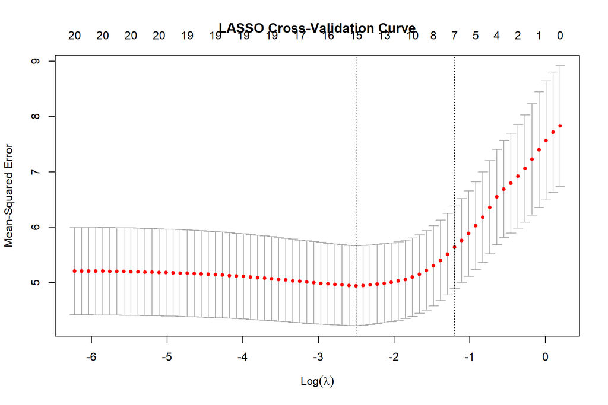

```r
set.seed(123)  # Important: CV folds are random
cv_fit <- cv.glmnet(
  x      = x_train,
  y      = y_train,
  alpha  = 1,       # alpha = 1 → LASSO; alpha = 0 → Ridge
  nfolds = 10       # 10-fold cross-validation
)

# Plot the cross-validation curve with log(lambda) on the x-axis
# sign.lambda = 1 uses log(lambda); the default (-1) flips it to -log(lambda)
plot(cv_fit, sign.lambda = 1, main = "LASSO Cross-Validation Curve")
```

### 4.4.1 Understanding the CV Plot

- As you move **left** (smaller $\lambda$, less penalty), more predictors remain in the model
- As you move **right** (larger $\lambda$, more penalty), more predictors are shrunk to zero
- `lambda.min` (less penalty) retains **more** non-zero predictors — it minimizes CV error
- `lambda.1se` (more penalty) retains **fewer** non-zero predictors — it gives the sparsest model within 1 SE of the minimum error
- The numbers along the top show how many predictors are non-zero at each $\lambda$

```r
cat("lambda.min:", cv_fit$lambda.min, "\n")
```

```
## lambda.min: 0.08186584
```

```r
cat("lambda.1se:", cv_fit$lambda.1se, "\n")
```

```
## lambda.1se: 0.3011337
```

## 4.5 Examining the Coefficients

```r
# Coefficients at lambda.min (less sparse, better fit)
coef_min <- coef(cv_fit, s = "lambda.min")
cat("=== Coefficients at lambda.min ===\n")
```

```
## === Coefficients at lambda.min ===
```

```r
cat("Non-zero predictors:", sum(coef_min[-1] != 0), "out of", p, "\n\n")
```

```
## Non-zero predictors: 15 out of 20
```

```r
# Coefficients at lambda.1se (sparser, more parsimonious)
coef_1se <- coef(cv_fit, s = "lambda.1se")
cat("=== Coefficients at lambda.1se ===\n")
```

```
## === Coefficients at lambda.1se ===
```

```r
cat("Non-zero predictors:", sum(coef_1se[-1] != 0), "out of", p, "\n")
```

```
## Non-zero predictors: 7 out of 20
```

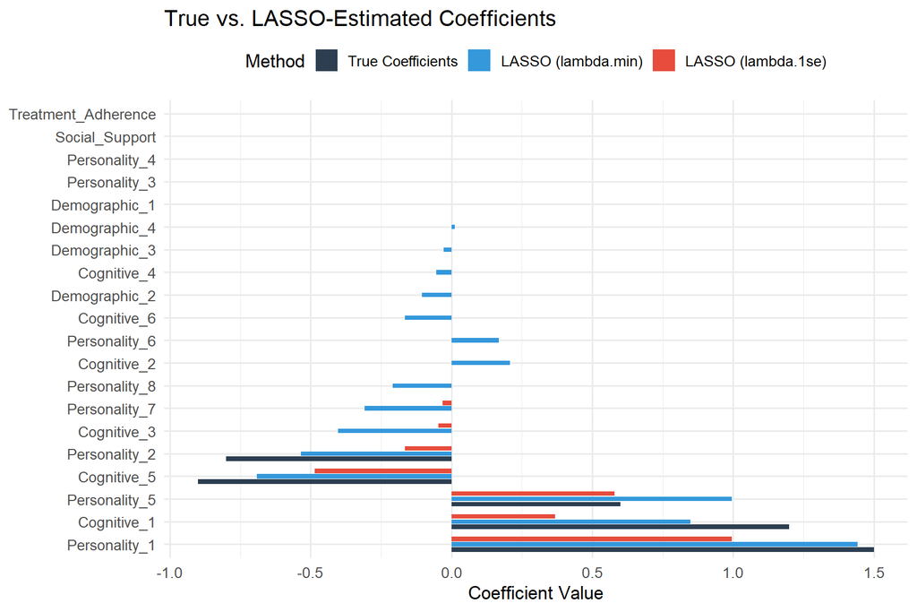

Comparison of true coefficients vs LASSO estimates

```r
# Build comparison data frame
coef_df <- data.frame(
  Predictor = colnames(X),
  True = true_betas,
  LASSO_min = as.numeric(coef_min[-1]),
  LASSO_1se = as.numeric(coef_1se[-1])
)

# Reshape for plotting
coef_long <- tidyr::pivot_longer(
  coef_df,
  cols = c(True, LASSO_min, LASSO_1se),
  names_to = "Method",
  values_to = "Coefficient"
)
coef_long$Method <- factor(coef_long$Method,
  levels = c("True", "LASSO_min", "LASSO_1se"),
  labels = c("True Coefficients", "LASSO (lambda.min)", "LASSO (lambda.1se)")
)

ggplot(coef_long, aes(x = reorder(Predictor, -abs(Coefficient)), y = Coefficient, fill = Method)) +
  geom_bar(stat = "identity", position = position_dodge(width = 0.7), width = 0.6) +
  coord_flip() +
  scale_fill_manual(values = c("#2c3e50", "#3498db", "#e74c3c")) +
  labs(
    title = "True vs. LASSO-Estimated Coefficients",
    x = NULL,
    y = "Coefficient Value"
  ) +
  theme_minimal(base_size = 13) +
  theme(legend.position = "top")
```

## 4.6 Coefficient Path Plot

[figure not shown]

```r
fit_full <- glmnet(x_train, y_train, alpha = 1)

# Reverse xlim so the x-axis goes from small log(lambda) on the left
# to large log(lambda) on the right, matching the CV plot orientation
log_lam_range <- range(log(fit_full$lambda))
plot(fit_full, xvar = "lambda", label = TRUE, main = "LASSO Coefficient Paths",
     xlim = rev(log_lam_range))
abline(v = log(cv_fit$lambda.min), lty = 2, col = "blue")
abline(v = log(cv_fit$lambda.1se), lty = 2, col = "red")
legend("topleft", legend = c("lambda.min", "lambda.1se"),
       col = c("blue", "red"), lty = 2, cex = 0.8)
```

## 4.7 Evaluating Prediction Performance

```r
# Predictions on test set
pred_lasso_min <- predict(cv_fit, newx = x_test, s = "lambda.min")
pred_lasso_1se <- predict(cv_fit, newx = x_test, s = "lambda.1se")

# Also fit OLS for comparison
ols_fit <- lm(y_train ~ x_train)
pred_ols <- cbind(1, x_test) %*% coef(ols_fit)

# Calculate RMSE and R-squared
rmse <- function(actual, predicted) sqrt(mean((actual - predicted)^2))
rsq  <- function(actual, predicted) 1 - sum((actual - predicted)^2) / sum((actual - mean(actual))^2)

results <- data.frame(
  Method = c("OLS", "LASSO (lambda.min)", "LASSO (lambda.1se)"),
  RMSE = c(
    rmse(y_test, pred_ols),
    rmse(y_test, pred_lasso_min),
    rmse(y_test, pred_lasso_1se)
  ),
  R_squared = c(
    rsq(y_test, pred_ols),
    rsq(y_test, pred_lasso_min),
    rsq(y_test, pred_lasso_1se)
  ),
  Predictors_Used = c(
    p,
    sum(coef_min[-1] != 0),
    sum(coef_1se[-1] != 0)
  )
)

knitr::kable(results, digits = 3, caption = "Prediction Performance on Test Set")
```

Prediction Performance on Test Set

| Method | RMSE | R_squared | Predictors_Used |
| --- | --- | --- | --- |
| OLS | 2.284 | 0.455 | 20 |
| LASSO (lambda.min) | 2.240 | 0.476 | 15 |
| LASSO (lambda.1se) | 2.406 | 0.395 | 7 |

# 5 Select-Then-Refit Workflow

A common workflow in psychology: use LASSO for variable selection, then refit with OLS for interpretable estimates.

```r
# Get selected variables at lambda.1se
lasso_coefs <- coef(cv_fit, s = "lambda.1se")
selected <- rownames(lasso_coefs)[which(lasso_coefs != 0)]
selected <- selected[selected != "(Intercept)"]

cat("Selected predictors:\n")
```

```
## Selected predictors:
```

```r
cat(paste(" -", selected), sep = "\n")
```

```
##  - Personality_1
##  - Personality_2
##  - Personality_5
##  - Personality_7
##  - Cognitive_1
##  - Cognitive_3
##  - Cognitive_5
```

```r
# Refit with OLS using only the selected predictors
if (length(selected) > 0) {
  df_train <- data.frame(Therapy_Outcome = y_train, x_train)

  formula_selected <- as.formula(
    paste("Therapy_Outcome ~", paste(selected, collapse = " + "))
  )

  ols_refit <- lm(formula_selected, data = df_train)

  cat("\n=== OLS Refit on LASSO-Selected Variables ===\n\n")
  summary(ols_refit)
} else {
  cat("No predictors were selected at lambda.1se.\n")
}
```

```
##
## === OLS Refit on LASSO-Selected Variables ===
```

```
##
## Call:
## lm(formula = formula_selected, data = df_train)
##
## Residuals:
##     Min      1Q  Median      3Q     Max
## -4.5449 -1.4500 -0.0139  1.2979  4.7589
##
## Coefficients:
##               Estimate Std. Error t value Pr(>|t|)
## (Intercept)    -0.2632     0.1753  -1.501 0.135738
## Personality_1   1.6108     0.2310   6.974 1.33e-10 ***
## Personality_2  -0.6086     0.1885  -3.228 0.001573 **
## Personality_5   1.1010     0.2048   5.375 3.36e-07 ***
## Personality_7  -0.4226     0.1780  -2.374 0.019013 *
## Cognitive_1     0.9573     0.2115   4.526 1.33e-05 ***
## Cognitive_3    -0.5772     0.1987  -2.905 0.004310 **
## Cognitive_5    -0.8107     0.2127  -3.812 0.000211 ***
## ---
## Signif. codes:  0 '***' 0.001 '**' 0.01 '*' 0.05 '.' 0.1 ' ' 1
##
## Residual standard error: 2.05 on 132 degrees of freedom
## Multiple R-squared:  0.4873, Adjusted R-squared:  0.4601
## F-statistic: 17.92 on 7 and 132 DF,  p-value: < 2.2e-16
```

> **Caveat:** The p-values and confidence intervals from this refitted model are **optimistic** because the variable selection step is not accounted for. This two-step procedure does not have the same inferential guarantees as a pre-specified OLS model. For valid post-selection inference, consider packages like `selectiveInference`.

# 6 Comparing LASSO, Ridge, and Elastic Net

```r
set.seed(123)

# LASSO (alpha = 1)
cv_lasso <- cv.glmnet(x_train, y_train, alpha = 1)

# Ridge (alpha = 0)
cv_ridge <- cv.glmnet(x_train, y_train, alpha = 0)

# Elastic Net (alpha = 0.5)
cv_enet <- cv.glmnet(x_train, y_train, alpha = 0.5)

# Compare
comparison <- data.frame(
  Method = c("LASSO (α=1)", "Elastic Net (α=0.5)", "Ridge (α=0)"),
  Lambda_min = c(cv_lasso$lambda.min, cv_enet$lambda.min, cv_ridge$lambda.min),
  CV_Error = c(
    min(cv_lasso$cvm),
    min(cv_enet$cvm),
    min(cv_ridge$cvm)
  ),
  Nonzero_Coefs = c(
    sum(coef(cv_lasso, s = "lambda.min")[-1] != 0),
    sum(coef(cv_enet, s = "lambda.min")[-1] != 0),
    sum(coef(cv_ridge, s = "lambda.min")[-1] != 0)
  )
)

knitr::kable(comparison, digits = 4, caption = "Comparison of Regularization Methods")
```

Comparison of Regularization Methods

| Method | Lambda_min | CV_Error | Nonzero_Coefs |
| --- | --- | --- | --- |
| LASSO (α=1) | 0.0819 | 4.9439 | 15 |
| Elastic Net (α=0.5) | 0.0937 | 4.8914 | 16 |
| Ridge (α=0) | 0.2808 | 4.9255 | 20 |

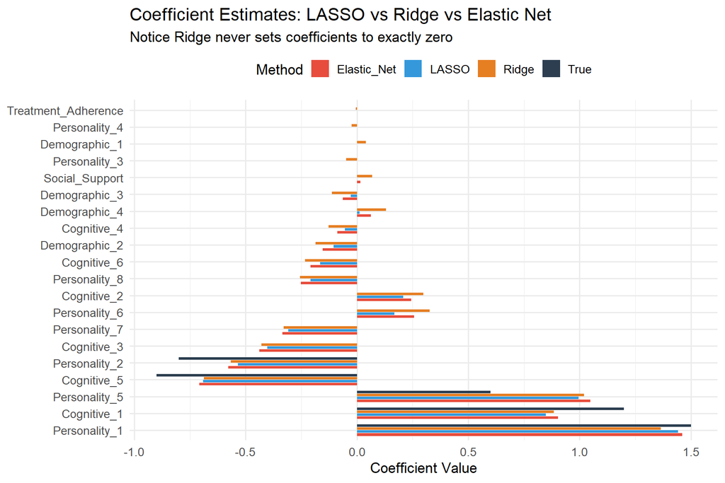

Coefficient estimates across methods

```r
coef_compare <- data.frame(
  Predictor = colnames(X),
  True = true_betas,
  LASSO = as.numeric(coef(cv_lasso, s = "lambda.min")[-1]),
  Ridge = as.numeric(coef(cv_ridge, s = "lambda.min")[-1]),
  Elastic_Net = as.numeric(coef(cv_enet, s = "lambda.min")[-1])
)

coef_compare_long <- tidyr::pivot_longer(
  coef_compare,
  cols = c(True, LASSO, Ridge, Elastic_Net),
  names_to = "Method",
  values_to = "Coefficient"
)

ggplot(coef_compare_long, aes(x = reorder(Predictor, -abs(Coefficient)), y = Coefficient, fill = Method)) +
  geom_bar(stat = "identity", position = position_dodge(width = 0.7), width = 0.6) +
  coord_flip() +
  scale_fill_manual(values = c("#e74c3c", "#3498db", "#e67e22", "#2c3e50")) +
  labs(
    title = "Coefficient Estimates: LASSO vs Ridge vs Elastic Net",
    subtitle = "Notice Ridge never sets coefficients to exactly zero",
    x = NULL,
    y = "Coefficient Value"
  ) +
  theme_minimal(base_size = 13) +
  theme(legend.position = "top")
```

# 7 Tuning Alpha for Elastic Net

When you have correlated predictors (common in psychology), tuning both $\alpha$ and $\lambda$ can improve results.

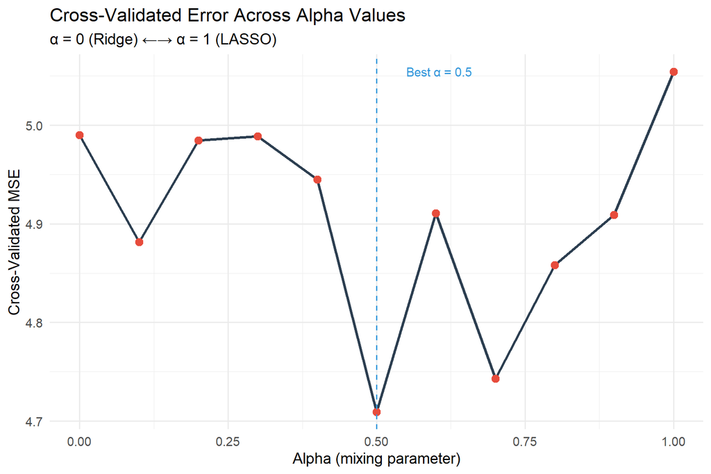

CV Error across different alpha values

```r
alphas <- seq(0, 1, by = 0.1)
cv_errors <- sapply(alphas, function(a) {
  cv <- cv.glmnet(x_train, y_train, alpha = a)
  min(cv$cvm)
})

alpha_df <- data.frame(Alpha = alphas, CV_Error = cv_errors)

ggplot(alpha_df, aes(x = Alpha, y = CV_Error)) +
  geom_line(color = "#2c3e50", linewidth = 1.2) +
  geom_point(color = "#e74c3c", size = 3) +
  geom_vline(xintercept = alphas[which.min(cv_errors)], linetype = "dashed", color = "#3498db") +
  annotate("text",
    x = alphas[which.min(cv_errors)] + 0.05,
    y = max(cv_errors),
    label = paste("Best α =", alphas[which.min(cv_errors)]),
    hjust = 0, color = "#3498db", size = 4
  ) +
  labs(
    title = "Cross-Validated Error Across Alpha Values",
    subtitle = "α = 0 (Ridge) ←→ α = 1 (LASSO)",
    x = "Alpha (mixing parameter)",
    y = "Cross-Validated MSE"
  ) +
  theme_minimal(base_size = 14)
```

# 8 Practical Checklist for Psychology Researchers

## 8.1 Before Using LASSO

- **Is your goal prediction or variable selection?** LASSO is optimized for these. For confirmatory hypothesis testing, consider pre-registered OLS.
- **Do you have more predictors than you’re comfortable including in OLS?** If yes, LASSO can help.
- **Are your predictors correlated?** If heavily correlated, consider Elastic Net instead of pure LASSO.
- **Is your sample size adequate?** LASSO works with smaller samples than OLS, but very small $n$ (< 50) can still be problematic.

## 8.2 During Analysis

- **Standardize your predictors** — `glmnet` does this internally by default, but be aware of it.
- **Set a seed** before `cv.glmnet()` for reproducibility.
- **Consider `lambda.1se`** for a more parsimonious model (preferred for interpretation).
- **Compare LASSO, Ridge, and Elastic Net** — report why you chose your method.

## 8.3 When Reporting

- **Do not report LASSO coefficients with p-values** unless using post-selection inference methods.
- **Report the CV procedure** — number of folds, which $\lambda$ was chosen, and why.
- **Report prediction performance** — RMSE, $R^2$, on a held-out test set or via CV.
- **List which variables were selected** and which were shrunk to zero.

# 9 Recommended Reading

- **Tibshirani, R. (1996).** Regression shrinkage and selection via the Lasso. *Journal of the Royal Statistical Society: Series B*, 58(1), 267-288.
- **Zou, H., & Hastie, T. (2005).** Regularization and variable selection via the elastic net. *Journal of the Royal Statistical Society: Series B*, 67(2), 301-320.
- **Hastie, T., Tibshirani, R., & Friedman, J. (2009).** *The Elements of Statistical Learning* (2nd ed.). Springer. [Free online](https://hastie.su.stanford.edu/ElemStatLearn/)
- **McNeish, D. M. (2015).** Using Lasso for predictor selection and to assuage overfitting: A method long overlooked in behavioral sciences. *Multivariate Behavioral Research*, 50(5), 471-484.

*Generated with R Markdown — A practical resource for psychology researchers interested in regularized regression methods.*